# Predicting the March Madness Bracket

### Analysis by Alexander Tanimoto

## Introduction

The **NCAA Division I men's basketball tournament**, otherwise branded as **NCAA March Madness**, is a 68 team tournament that determines the NCAA Division I national champion for college basketball. First, the Selection Committee selects 68 teams to participate in the tournament, ranking each from 1 to 68. Based on the rankings, the committee then divides the teams into four regions: East, South, Midwest, and West. In each region, teams are seeded from No. 1 to No. 16. As of 2011, eight teams will share a seed numbering with another team in the same region, and they will compete in a First Four round. This round returns four victorious teams, leaving 64 teams remaining and thus the standard single-elimination bracket. More information about the tournament can be found [here](https://en.wikipedia.org/wiki/NCAA_Division_I_men%27s_basketball_tournament).

Here is an illustration of what the March Madness bracket looks like. This is the final bracket for the 2022 March Madness tournament (which I will do my best to replicate later in the analysis). This image was taken from the [official NCAA website](https://www.ncaa.com/news/basketball-men/mml-official-bracket/2022-04-05/2022-ncaa-tournament-bracket-schedule-scores-march-madness).

[figure not shown]

Each year the challenge takes place, NCAA hosts the [official bracket challenge](https://www.ncaa.com/march-madness-live/bcg) before the tournament, allowing fans to predict the outcome of every game. Third party websites like [ESPN](https://fantasy.espn.com/tournament-challenge-bracket/2022/en/) and [CBS Sports](https://picks.cbssports.com/college-basketball/ncaa-tournament/bracket) also host the challenge. While a seemingly trivial challenge, this tournament attracts over 35 million participants each year. [The investment guru Warren Buffet himself initiated a bracket challenge in 2014 for employees of Berkshire Hathaway, promising to pay an employee that predicted every outcome correctly \$1 million every year, for life](https://www.investopedia.com/ask/answers/082714/what-are-odds-getting-perfect-bracket-warren-buffetts-1-billion-march-madness-bracket-challenge.asp). Even though the odds of predicting each game correctly are astronomically small (1 in $2^{63}$ for 63 games, not including the First Four), I imagine most participants go into the challenge believing that their bracket will be the one. I believe the adrenaline rush of potentially achieving such an improbable feet is what makes this challenge so popular. The rise of sports betting has certainly aided in its popularity, as now many participants have a monetary incentive to predict correctly.

I am no exception to the madness that consumes the March Madness challenge. Last year, I participated in University of Maryland's Bracket Challenge for University Honors on ESPN. While I was unsuccessful in placing, I came out of the challenge more motivated than every to win a free pair of AirPods. Next time, I'll have a secret weapon unthinkable to everyone else: a model to predict the tournament for me.

My model is the result of doing a walkthrough of Kaggle's [March Madness Learning Mania](https://www.kaggle.com/competitions/mens-march-mania-2022) competition.

## Datasets

Since 2015, Kaggle has hosted the March Madness Learning Mania competition, allowing machine learning enthusiasts to predict the outcome of the year's tournament (they also host one for women as well [here](https://www.kaggle.com/c/34542)). I am fortunate to have all the data I need to conduct the analysis I need from the datasets provided by Kaggle. Datasets can be found [here](https://www.kaggle.com/competitions/mens-march-mania-2022/data?select=MDataFiles_Stage2), which also provide more information about the datasets if necessary. Note that as this analysis occurs after the tournament, we will be using datasets under **Stage 2**. Also note that not all datasets will be relevant for this analysis.

Before I go into depth with the datasets, we need to import `pandas` to read the CSV data files. The `pandas` library is an essential library for data science techniques. For full documentation details, see [here](https://pandas.pydata.org/).

```python
import pandas as pd
```

### Teams

One of the attached datasets is `MTeams.csv`, which stores all Division-I men's basketball teams ever recorded. Hence, it may include former D1 teams that were removed from the list. This will serve as a lookup table, i.e. if we need to look up a team name when primarily working with team IDs.

```python
teams = pd.read_csv('MTeams.csv')
teams.head()
```

|  | TeamID | TeamName | FirstD1Season | LastD1Season |
| --- | --- | --- | --- | --- |
| 0 | 1101 | Abilene Chr | 2014 | 2022 |
| 1 | 1102 | Air Force | 1985 | 2022 |
| 2 | 1103 | Akron | 1985 | 2022 |
| 3 | 1104 | Alabama | 1985 | 2022 |
| 4 | 1105 | Alabama A&M | 2000 | 2022 |

Here is a breakdown of the features.

- **TeamID** - A four-digit unique ID for each team, ranging from 1000-1999. This is the primary identifier of a team in the rest of the datasets.
- **TeamName** - The name of the team identified by the ID. This will be what we "lookup" later on when finding the team name associated with an ID.
- **FirstD1Season** - The first season (as far back as the dataset was recorded) the team was a D1 team. Won't be important for analysis.
- **LastD1Season** - The last season (or 2022 if current) the team was a D1 team. Again, not important for analysis.

### Seasons

The next dataset is `MSeasons.csv`, storing important information for each season recorded.

```python
seasons = pd.read_csv('MSeasons.csv')
seasons.head()
```

|  | Season | DayZero | RegionW | RegionX | RegionY | RegionZ |
| --- | --- | --- | --- | --- | --- | --- |
| 0 | 1985 | 1984-10-29 00:00:00 | East | West | Midwest | Southeast |
| 1 | 1986 | 1985-10-28 00:00:00 | East | Midwest | Southeast | West |
| 2 | 1987 | 1986-10-27 00:00:00 | East | Southeast | Midwest | West |
| 3 | 1988 | 1987-11-02 00:00:00 | East | Midwest | Southeast | West |
| 4 | 1989 | 1988-10-31 00:00:00 | East | West | Midwest | Southeast |

And a breakdown here.

- **Season** - The year the tournament was played. Note that the season starts the year before and ends on the year of the tournament.
- **DayZero** - The first day of the season. Notice how it occurs the year before the "season" year.
- **RegionW**, **RegionX**, **RegionY**, **RegionZ** - The regions marked for the tournament. This won't be that important for the analysis, but for reference the regions are ordered in the following manner.
  - **RegionW** - The first region in alphabetical order.
  - **RegionX** - The region that plays **RegionW** in the Final Four (semifinals), as determined by the tournament.
  - **RegionY** - The next unique region in alphabetical order.
  - **RegionZ** - The region that plays **RegionY** in the Final Four.

### Tournament Seeds

Another dataset we will explore is `MNCAATourneySeeds.csv`, which identifies the seeds for all the teams in the tournament for each tournament year recorded. So each tournament year will have 64-68 teams. This dataset is going to be a building point for concatenating team stats for each of the teams seeded in the tournament (since 2003).

```python
tourney_seeds = pd.read_csv('MNCAATourneySeeds.csv')
tourney_seeds.head()
```

|  | Season | Seed | TeamID |
| --- | --- | --- | --- |
| 0 | 1985 | W01 | 1207 |
| 1 | 1985 | W02 | 1210 |
| 2 | 1985 | W03 | 1228 |
| 3 | 1985 | W04 | 1260 |
| 4 | 1985 | W05 | 1374 |

Here is a breakdown of the features.

- **Season** - The year the tournament took place.
- **Seed** - A 3-4 character identifier of the seed. The first character is W, X, Y, or Z, keys for the region (which is mapped in the `MSeasons.csv` table). The next two digits indicate the seed in the region, from 1-16. If applicable, the last character will be an 'a' or 'b' to indicate competing seeds during the play-in games in the First Four.
- **TeamID** - The ID of the team with the given seed.

### Regular Season Results

The `MRegularSeasonDetailedResults.csv` dataset shows box scores (game-by-game stats) for all regular season and conference tournament. This will be our central resource for accumulating team stats for all the tournament seeds.

```python
box_scores = pd.read_csv('MRegularSeasonDetailedResults.csv')
box_scores.head()
```

|  | Season | DayNum | WTeamID | WScore | LTeamID | LScore | WLoc | NumOT | WFGM | WFGA | ... | LFGA3 | LFTM | LFTA | LOR | LDR | LAst | LTO | LStl | LBlk | LPF |
| --- | --- | --- | --- | --- | --- | --- | --- | --- | --- | --- | --- | --- | --- | --- | --- | --- | --- | --- | --- | --- | --- |
| 0 | 2003 | 10 | 1104 | 68 | 1328 | 62 | N | 0 | 27 | 58 | ... | 10 | 16 | 22 | 10 | 22 | 8 | 18 | 9 | 2 | 20 |
| 1 | 2003 | 10 | 1272 | 70 | 1393 | 63 | N | 0 | 26 | 62 | ... | 24 | 9 | 20 | 20 | 25 | 7 | 12 | 8 | 6 | 16 |
| 2 | 2003 | 11 | 1266 | 73 | 1437 | 61 | N | 0 | 24 | 58 | ... | 26 | 14 | 23 | 31 | 22 | 9 | 12 | 2 | 5 | 23 |
| 3 | 2003 | 11 | 1296 | 56 | 1457 | 50 | N | 0 | 18 | 38 | ... | 22 | 8 | 15 | 17 | 20 | 9 | 19 | 4 | 3 | 23 |
| 4 | 2003 | 11 | 1400 | 77 | 1208 | 71 | N | 0 | 30 | 61 | ... | 16 | 17 | 27 | 21 | 15 | 12 | 10 | 7 | 1 | 14 |

5 rows × 34 columns

This is a pretty lengthy dataset, but many of the features repeat themselves.

- **Season** - Indicates the year the tournament took place for that season. Note that a season starts the year before.
- **DayNum** - The number of days since the first day of the season, which has **DayNum=0**.
- **WTeamID**/**LTeamID** - The team ID of the winning/losing team.
- **WScore**/**LScore** - Points scored (by the winning/losing team).
- **WFGM**/**LFGM** - Field goals made (by the winning/losing team).
- **WFGA**/**LFGA** - Field goals attempted (by the winning/losing team).
- **WFGM3**/**LFGM3** - Three pointers made (by the winning/losing team).
- **WFGA3**/**LFGA3** - Three pointers attempted (by the winning/losing team).
- **WFTM**/**LFTM** - Free throws made (by the winning/losing team).
- **WFTA**/**LFTA** - Free throws attempted (by the winning/losing team).
- **WOR**/**LOR** - Offensive rebounds pulled (by the winning/losing team).
- **WDR**/**LDR** - Defensive rebounds pulled (by the winning/losing team).
- **WASt**/**LAst** - Assists (by the winning/losing team).
- **WTO**/**LTO** - Turnovers committed (by the winning/losing team).
- **WStl**/**LStl** - Steals (by the winning/losing team).
- **WBlk**/**LBlk** - Blocks (by the winning/losing team).
- **WPF**/**LPF** - Personal fouls committed (by the winning/losing team).
- **WLoc** - The location the game was played in the perspective of the winning team. Not important for analysis, but in case, here is the breakdown.
  - **H** - Winning team was the home team.
  - **A** - Winning team was the away team.
  - **N** - Game played in a neutral site.
- **NumOT** - Number of overtime periods, an integer 0 or higher. Not important for analysis.

### Tournament Results

The `MNCAATourneyCompactResults.csv` has results for NCAA tournament games since 1985. This dataset does not have box scores, however, because we are only concerned about the result for those games. The result of the tournament games is our dependent variable. The independent variables, or *features*, are the pre-game statistics of the competing teams.

```python
tourney_results = pd.read_csv('MNCAATourneyCompactResults.csv')
tourney_results.head()
```

|  | Season | DayNum | WTeamID | WScore | LTeamID | LScore | WLoc | NumOT |
| --- | --- | --- | --- | --- | --- | --- | --- | --- |
| 0 | 1985 | 136 | 1116 | 63 | 1234 | 54 | N | 0 |
| 1 | 1985 | 136 | 1120 | 59 | 1345 | 58 | N | 0 |
| 2 | 1985 | 136 | 1207 | 68 | 1250 | 43 | N | 0 |
| 3 | 1985 | 136 | 1229 | 58 | 1425 | 55 | N | 0 |
| 4 | 1985 | 136 | 1242 | 49 | 1325 | 38 | N | 0 |

### Sample Submission

Finally we have a sample submission file. This will not be used for data collection purposes; rather, it will give us a preview of the dataset we will try to create when we build our predictions. This dataset will ultimately serve to evaluate our model when submitted on the Kaggle challenge.

```python
sample = pd.read_csv('MSampleSubmissionStage2.csv')
sample.head()
```

|  | ID | Pred |
| --- | --- | --- |
| 0 | 2022_1103_1104 | 0.5 |
| 1 | 2022_1103_1112 | 0.5 |
| 2 | 2022_1103_1116 | 0.5 |
| 3 | 2022_1103_1120 | 0.5 |
| 4 | 2022_1103_1124 | 0.5 |

And the breakdown.

- **ID** - The ID of the March Madness game, given in the format *SSSS_XXXX_YYYY*
  - **SSSS** - The season the tournament game is played.
  - **XXXX** - The Team ID of the team with the numerically smaller ID.
  - **YYYY** - The Team ID of the team with the numerically larger ID.
- **Pred** - The prediction for the game.
  - A prediction closer to 1 means that team **XXXX** is more likely to win.
  - A prediction closer to 0 means that team **YYYY** is more likely to win.

Here's an important note. Remember how the tournament begins with 68 teams. Each team could play 67 possible teams. This dataset is actually predicting the probability of a team winning for every single *possible* matchup. There are **68 * 67 / 2 = 2278** possible matchups, so that is the number of rows we want in our dataset.

## Data Preprocessing

### Four Factors

If you looked at the `MRegularSeasonDetailedResults.csv` dataset, you'll notice how many stats we have for one game alone. Fortunately, we won't look at every one of them. Not only would that be an infeasible number of features to study, but having too features increases the model complexity and would lead to overfitting.

One way to predict the outcome would be to look at a strength of a team and then compare the rating of two teams. Creating a raating system, however, is beyond the scope of this project. We are not really concerned with looking at the strength of individual teams, but rather how the team stats interact with each other. For example, maybe a rating system rates Team A higher than Team B when looking at a certain set of team stats, but based on how a different set of team stats compare, Team B may be suited to beat Team A. We are more concerned with the latter: how the team stats compare in the matchup.

For each team, we will be using a philosophy called **Four Factors** to determine the strength of each basketball team. This philosophy was introduced by Dean Oliver, who claimed that these four factors were what determined basketball success (eight since we apply each to both offense and defense equally), along with their weights as to how much they each contributed to success. We are not worried about the weights for this project, because technically this is what our machine learning model will try to figure out. For more information, look [here](https://www.basketball-reference.com/about/factors.html).

- **Shooting** (40%, 20% each for offense and defense)
- **Turnovers** (25%, 12.5% each)
- **Rebounding** (20%, 10% each)
- **Free Throws** (15%, 7.5% each)

Many rating systems use a combination of *point differentials* and *strength of victory* when accounting for the strength of teams. I think the **Four Factors** helps explain these two features pretty well. The four factors are what explain *point differential*. In terms of *strength of victory*, I want you to imagine the difference between the NBA playoffs and a street basketball tournament. Both may have similar *point differentials* and *strength of victory* stats due to the teams in the respective tournament. However, the NBA tournmanet probably features, for example, much better shooting efficiency and many less turnovers.

This is another reason why I want to use the **Four Factors** rather than a rating system: it allows us to analyze more features across teams than just *point differential* and *strength of victory*, and thus makes for a more interesting model.

#### Shooting

The factor is measured by **Effective Field Goal Percentage (EFGP)**. The formula for both offense and defense is given as: **EFGP = (FGM + 0.5 * FG3M) / FGA**. The goal is to maximize **EFGP** for offense (**OEFGP**) and minimize **EFGP** for defense (**DEFGP**).

#### Turnovers

The factor is measured by the **Turnover Percentage (TOP)**. The formula for both offense and defense is given as: **TOP = TO / (FGA + 0.44 * FTA + TO)**. The goal is to now *minimize* **TOP** for offense (**OTOP**) and *maximize* **TOP** for defense (**DTOP**).

#### Rebounding

The factor is measured by rebounding percentages for both offense and defense (**ORP** and **DRP**, respectively). The formulas are as follows:

- **ORP** = **OR / (OR + Opp DR)**
- **DRP** = **DR / (DR + Opp OR)**

This time we want to maximize *both* percentages.

#### Free Throws

This factor is underratedly important. Being able to draw fouls and get to the line is an important skill of basketball. Of course, making the shots are also important. And on the other hand, you rather not have the majority of the opponent's shots come from free throws. For both offense and defense, the formula is the percentage of free throws made out of field goals attempted, which I will dub the **free throw factor** because I am that creative: **FTF = FTM / FGA**. The goal is to maximize the offensive **FTF** (**OFTF**) and minimize the defensive **FTF** (**DFTF**).

### Data Aggregation

The plan is that we need to create a DataFrame that stores the eight features for each seed in the March Madness tournament since 2003. From here on out, we only care about data since 2003 because we only have the box scores for those years onwards.

```python
# Data from seeds DataFrame needed in our aggregated DataFrame

# Season
seasons = []

# Seed
seeds = []

# TeamID
team_ids = []

# TeamName (for data representation purposes)
team_names = []
```

```python
# Eight factors for each team in the tournament, for each season since 2003

# Offensive Effective Field Goal Percentage
oefgp = []

# Defensive Effective Field Goal Percentage
defgp = []

# Offensive Turnover Percentage
otop = []

# Defensive Turnover Percentage
dtop = []

# Offesive Rebound Percentage
orp = []

# Defensive Rebound Percentage
drp = []

# Offensive Free Throw Factor
oftf = []

# Defensive Free Throw Factor
dftf = []
```

Based on the data we are trying to collect to calculate the eight factors, we need to accumulate the following team *and* opponent stats for the season:

- **FGM**
- **FGA**
- **FG3M**
- **FTM**
- **FTA**
- **OR**
- **DR**
- **TO**

From here on out, we aggregate the team stats for all teams in the tournament for the given season. First we define a helper function to aggregate team stats for the season from a given game.

```python
def agg_game_stats(season_stats, team_id, game_index, t, o):
    '''
    This function will aggregate the team stats for the team identified by team_id in the season_stats dictionary parameter,
    based on the game identified by the game_index parameter. It does this by retrieving the appropriate column for the stats
    in the box_scores DataFrame. Note that t = team result ('W' or 'L'), o = opponent result.
    '''

    def agg_team_opp_stat(stat):
        '''
        This local function aggregates a season stat for both the team and opponent
        '''

        season_stats[team_id][f'T{stat}'] += box_scores[f'{t}{stat}'][game_index]
        season_stats[team_id][f'O{stat}'] += box_scores[f'{o}{stat}'][game_index]

    # Aggregate for eight stats, both for team and opponent
    agg_team_opp_stat('FGM')
    agg_team_opp_stat('FGA')
    agg_team_opp_stat('FGM3')
    agg_team_opp_stat('FTM')
    agg_team_opp_stat('FTA')
    agg_team_opp_stat('OR')
    agg_team_opp_stat('DR')
    agg_team_opp_stat('TO')
```

```python
def calc_efgp(season_stats, team_id, p):
    '''
    Returns the effective field goal percentage given by the perspective passed in as 'p' (team or opponent).
    '''

    return (season_stats[team_id][f'{p}FGM'] + 0.5 * season_stats[team_id][f'{p}FGM3']) / season_stats[team_id][f'{p}FGA']
```

```python
def calc_top(season_stats, team_id, p):
    '''
    Returns the turnover percentage given by the perspective passed in as 'p' (team or opponent).
    '''

    return (season_stats[team_id][f'{p}TO'] /
            (season_stats[team_id][f'{p}FGA'] + 0.44 * season_stats[team_id][f'{p}FTA'] + season_stats[team_id][f'{p}TO']))
```

```python
def calc_rp(season_stats, team_id, m0):
    '''
    Returns the rebound percentage for mode 'm0' (offense or defense).
    '''

    # Define opponent mode opposite to team
    m1 = 'D' if m0 == 'O' else 'O'

    return season_stats[team_id][f'T{m0}R'] / (season_stats[team_id][f'T{m0}R'] + season_stats[team_id][f'O{m1}R'])
```

```python
def calc_ftf(season_stats, team_id, p):
    '''
    Returns the free throw factor given by the perspective passed in as 'p'.
    '''

    return season_stats[team_id][f'{p}FTM'] / season_stats[team_id][f'{p}FGA']
```

Now for the actual aggregation algorithm.

```python
# Aggregate stats for each seed, for each season since 2003
for season in tourney_seeds[tourney_seeds['Season'] >= 2003]['Season'].unique():

    # Get all unique teams in tourney for season
    tourney_team_ids = set(tourney_seeds[tourney_seeds['Season'] == season]['TeamID'].unique())

    # Store aggregation of season stats for each team in dictionary (includes opponent data)
    # The first letter in each stat is either a 'T' (for team) or an 'O' (for opponent)
    season_stats = dict()
    for tourney_team_id in tourney_team_ids:
        season_stats[tourney_team_id] = {
            'TFGM' : 0,
            'OFGM' : 0,
            'TFGA' : 0,
            'OFGA' : 0,
            'TFGM3': 0,
            'OFGM3': 0,
            'TFTM' : 0,
            'OFTM' : 0,
            'TFTA' : 0,
            'OFTA' : 0,
            'TOR'  : 0,
            'OOR'  : 0,
            'TDR'  : 0,
            'ODR'  : 0,
            'TTO'  : 0,
            'OTO'  : 0
        }

    # For each game during the regular season, accumulate into team stats for season
    for game_index in box_scores[box_scores['Season'] == season].index:
        w_team_id, l_team_id = box_scores['WTeamID'][game_index], box_scores['LTeamID'][game_index]

        # Aggregate winning team stats if winning team is seed
        if w_team_id in tourney_team_ids:
            agg_game_stats(season_stats, w_team_id, game_index, 'W', 'L')

         # Aggregate losing team stats if losing team is seed
        if l_team_id in tourney_team_ids:
            agg_game_stats(season_stats, l_team_id, game_index, 'L', 'W')

    # Append to lists in order of seed
    for seed_index in tourney_seeds[tourney_seeds['Season'] == season].index:
        seed, tourney_team_id = tourney_seeds['Seed'][seed_index], tourney_seeds['TeamID'][seed_index]

        # Append data to identify team
        # Accessing team name requires a lookup in the teams DataFrame
        seasons.append(season)
        seeds.append(seed)
        team_ids.append(tourney_team_id)
        team_names.append(teams[teams['TeamID'] == tourney_team_id]['TeamName'].values[0])

        # Append stats for team
        oefgp.append(calc_efgp(season_stats, tourney_team_id, 'T'))
        defgp.append(calc_efgp(season_stats, tourney_team_id, 'O'))
        otop.append(calc_top(season_stats, tourney_team_id, 'T'))
        dtop.append(calc_top(season_stats, tourney_team_id, 'O'))
        orp.append(calc_rp(season_stats, tourney_team_id, 'O'))
        drp.append(calc_rp(season_stats, tourney_team_id, 'D'))
        oftf.append(calc_ftf(season_stats, tourney_team_id, 'T'))
        dftf.append(calc_ftf(season_stats, tourney_team_id, 'O'))
```

And here we create the DataFrame with the aggregated data, called `detailed_tourney_seeds` since it has season stats for each seed.

```python
detailed_tourney_seeds = pd.DataFrame({
    'Season'  : seasons,
    'Seed'    : seeds,
    'TeamID'  : team_ids,
    'TeamName': team_names,
    'OEFGP'   : oefgp,
    'DEFGP'   : defgp,
    'OTOP'    : otop,
    'DTOP'    : dtop,
    'ORP'     : orp,
    'DRP'     : drp,
    'OFTF'    : oftf,
    'DFTF'    : dftf
})

detailed_tourney_seeds.head()
```

|  | Season | Seed | TeamID | TeamName | OEFGP | DEFGP | OTOP | DTOP | ORP | DRP | OFTF | DFTF |
| --- | --- | --- | --- | --- | --- | --- | --- | --- | --- | --- | --- | --- |
| 0 | 2003 | W01 | 1328 | Oklahoma | 0.512972 | 0.446284 | 0.154213 | 0.182023 | 0.351351 | 0.705938 | 0.232901 | 0.234853 |
| 1 | 2003 | W02 | 1448 | Wake Forest | 0.509940 | 0.458454 | 0.179679 | 0.166946 | 0.432760 | 0.683888 | 0.350000 | 0.214657 |
| 2 | 2003 | W03 | 1393 | Syracuse | 0.512195 | 0.443703 | 0.157975 | 0.165343 | 0.391140 | 0.630048 | 0.263304 | 0.194237 |
| 3 | 2003 | W04 | 1257 | Louisville | 0.529041 | 0.448183 | 0.156805 | 0.204783 | 0.358696 | 0.661106 | 0.287123 | 0.326980 |
| 4 | 2003 | W05 | 1280 | Mississippi St | 0.521804 | 0.458769 | 0.197411 | 0.208737 | 0.386179 | 0.692958 | 0.213859 | 0.193231 |

- **OEFGP**/**DEFGP** - Offensive/Defensive Effective Field Goal Percentage
- **OTOP**/**DTOP** - Offensive/Defensive Turnover Percentage
- **ORP**/**DRP** - Offensive/Defensive Rebounding Percentage
- **OFTF**/**DFTF** - Offensive/Defensive Free Throw Factor (**FTF = FTM / FGA**)

To illustrate an example use of this dataset, if we wanted to see the team stats for teams in the 2021 tournament, we can filter by season (filtered to top five entries).

```python
seeds_2021 = detailed_tourney_seeds[detailed_tourney_seeds['Season'] == 2021]
seeds_2021.head()
```

|  | Season | Seed | TeamID | TeamName | OEFGP | DEFGP | OTOP | DTOP | ORP | DRP | OFTF | DFTF |
| --- | --- | --- | --- | --- | --- | --- | --- | --- | --- | --- | --- | --- |
| 1132 | 2021 | W01 | 1276 | Michigan | 0.549168 | 0.449001 | 0.141047 | 0.124237 | 0.276353 | 0.784077 | 0.224873 | 0.183322 |
| 1133 | 2021 | W02 | 1104 | Alabama | 0.513165 | 0.453226 | 0.159876 | 0.175355 | 0.296860 | 0.722635 | 0.205989 | 0.218817 |
| 1134 | 2021 | W03 | 1400 | Texas | 0.528534 | 0.466601 | 0.171233 | 0.148798 | 0.304774 | 0.752486 | 0.240876 | 0.250000 |
| 1135 | 2021 | W04 | 1199 | Florida St | 0.543611 | 0.465116 | 0.172215 | 0.166581 | 0.343844 | 0.712951 | 0.241010 | 0.268992 |
| 1136 | 2021 | W05 | 1160 | Colorado | 0.520258 | 0.476829 | 0.137783 | 0.167239 | 0.279769 | 0.768069 | 0.246036 | 0.203659 |

Or let's say we wanted to see the season stats for the **Maryland Terrapins** for all years they competed in the tournament. We can filter by the **TeamName** (included for data exploration purposes).

```python
seeds_md = detailed_tourney_seeds[detailed_tourney_seeds['TeamName'] == 'Maryland']
seeds_md
```

|  | Season | Seed | TeamID | TeamName | OEFGP | DEFGP | OTOP | DTOP | ORP | DRP | OFTF | DFTF |
| --- | --- | --- | --- | --- | --- | --- | --- | --- | --- | --- | --- | --- |
| 21 | 2003 | X06 | 1268 | Maryland | 0.517756 | 0.432193 | 0.162234 | 0.207995 | 0.368069 | 0.651304 | 0.239572 | 0.239387 |
| 84 | 2004 | X04 | 1268 | Maryland | 0.481152 | 0.462757 | 0.167947 | 0.198710 | 0.381452 | 0.659266 | 0.252880 | 0.271262 |
| 295 | 2007 | Y04 | 1268 | Maryland | 0.526893 | 0.434837 | 0.183548 | 0.194044 | 0.360071 | 0.633588 | 0.274674 | 0.214536 |
| 448 | 2009 | Z10 | 1268 | Maryland | 0.467868 | 0.475460 | 0.151698 | 0.189114 | 0.350160 | 0.631321 | 0.212269 | 0.203988 |
| 491 | 2010 | Y04 | 1268 | Maryland | 0.519438 | 0.442903 | 0.143299 | 0.178435 | 0.352996 | 0.628967 | 0.245140 | 0.203308 |
| 829 | 2015 | Y04 | 1268 | Maryland | 0.508860 | 0.454188 | 0.163960 | 0.147823 | 0.291787 | 0.695688 | 0.336680 | 0.184293 |
| 898 | 2016 | Y05 | 1268 | Maryland | 0.556382 | 0.466737 | 0.169019 | 0.143527 | 0.302254 | 0.705139 | 0.270750 | 0.188490 |
| 951 | 2017 | X06 | 1268 | Maryland | 0.526102 | 0.471381 | 0.166556 | 0.154135 | 0.306375 | 0.677448 | 0.270302 | 0.226747 |
| 1069 | 2019 | W06 | 1268 | Maryland | 0.519415 | 0.459733 | 0.171827 | 0.126766 | 0.339458 | 0.752922 | 0.245920 | 0.190933 |
| 1141 | 2021 | W10 | 1268 | Maryland | 0.525676 | 0.484839 | 0.151448 | 0.143021 | 0.196386 | 0.760221 | 0.229054 | 0.183828 |

Too bad the dataset started recording stats one year after the year **Maryland** won the tournament. :-(

### Tournament Games

The next DataFrame we will create is the dataset of interest for machine learning. For each historical tournament since 2003 (so *pre-2022*), we will store for each tournament game, the *differences in team stats* across the season, as well as the actual result of the matchup. To understand the *differences in team stats*, remember how the games will be identified: using the **SSSS_XXXX_YYYY** format earlier. So the *difference in team stats* is the **team stat for XXXX - team stat for YYYY**. To illustrate with an example, if the *difference in offensive rebounding percentage* is positive, then **XXXX** has a larger offensive rebounding percentage than **YYYY**, and if it is negative, then **YYYY** has a larger offensive rebounding percentage than **XXXX**.

Now the *differences in team stats* are what are called *features*. These are the independent variables, the ones that our model will use to make predictions. Meanwhile, the result of the matchup is the *target*. This is the dependent variable, the one our model is trying to predict. Hence, our model is using the *differences in team differentials* to predict the result of the matchup. The result will be encoded as 0 or 1, where 1 means that team **XXXX** won, and 0 means that team **YYYY** won. More information about *features* and *targets* can be found [here](https://medium.com/technology-nineleaps/some-key-machine-learning-definitions-b524eb6cb48).

First we define the columns we need for our DataFrame.

```python
# Store matchup IDs
ids = []

# Deconstruct the ID for data representation purposes

# Seasons
seasons = []

# Names of teams with smaller ID (XXXX)
teams1 = []

# Names of teams with larger ID (YYYY)
teams2 = []
```

```python
# Store differences in team stats

# Offensive Effective Field Goal Percentage
oefgp = []

# Defensive Effective Field Goal Percentage
defgp = []

# Offensive Turnover Percentage
otop = []

# Defensive Turnover Percentage
dtop = []

# Offesive Rebound Percentage
orp = []

# Defensive Rebound Percentage
drp = []

# Offensive Free Throw Factor
oftf = []

# Defensive Free Throw Factor
dftf = []
```

```python
# Store results of tournament games
results = []

# Store team name of winner for data representation
winners = []
```

I'm going to use a helper function that appends the appropriate values to each of the feature lists. The reason will become more clear later, but essentially we will be using this function in more than one place.

```python
def add_features(season, team1_id, team2_id):
    '''
    This function appends to both the list of matchup IDs and the lists storing the differences in team differentials.
    A difference in team differentials is given as: team differential for min_team_id - team differential for max_team_id.

    Note that the target list is not used in this function, because the two DataFrames that call this function will use
    different target variables.
    '''

    # DataFrames for detailed stats for given team and season
    team1_id_stats = detailed_tourney_seeds[(detailed_tourney_seeds['Season'] == season) & (detailed_tourney_seeds['TeamID'] == team1_id)]
    team2_id_stats = detailed_tourney_seeds[(detailed_tourney_seeds['Season'] == season) & (detailed_tourney_seeds['TeamID'] == team2_id)]

    # All matchup IDs follow the same format
    # Also append to deconstructed ID lists
    ids.append(f'{season}_{team1_id}_{team2_id}')
    seasons.append(season)
    teams1.append(team1_id_stats['TeamName'].values[0])
    teams2.append(team2_id_stats['TeamName'].values[0])

    # Append to difference lists (team1_id stat - team2_id stat)
    oefgp.append(team1_id_stats['OEFGP'].values[0] - team2_id_stats['OEFGP'].values[0])
    defgp.append(team1_id_stats['DEFGP'].values[0] - team2_id_stats['DEFGP'].values[0])
    otop.append(team1_id_stats['OTOP'].values[0] - team2_id_stats['OTOP'].values[0])
    dtop.append(team1_id_stats['DTOP'].values[0] - team2_id_stats['DTOP'].values[0])
    orp.append(team1_id_stats['ORP'].values[0] - team2_id_stats['ORP'].values[0])
    drp.append(team1_id_stats['DRP'].values[0] - team2_id_stats['DRP'].values[0])
    oftf.append(team1_id_stats['OFTF'].values[0] - team2_id_stats['OFTF'].values[0])
    dftf.append(team1_id_stats['DFTF'].values[0] - team2_id_stats['DFTF'].values[0])
```

Great! Now we can actually construct the data for our DataFrame. Note that the result is done separate from the function because the second time we call the function, we will not keep track of the result.

```python
# Iterate through all tournament games since 2003
for result_index in tourney_results[tourney_results['Season'] >= 2003].index:
    season = tourney_results['Season'][result_index]
    team_ids = (tourney_results['WTeamID'][result_index], tourney_results['LTeamID'][result_index])
    team1_id, team2_id = min(team_ids), max(team_ids)

    # Add matchup ID and features for tournament game
    add_features(season, team1_id, team2_id)

    # Encode the result as 1 (if min_id won) or 0 (if min_id lost)
    # Also append to winners for data representation
    results.append(1 if team1_id == team_ids[0] else 0)
    winners.append(teams[teams['TeamID'] == team_ids[0]]['TeamName'].values[0])
```

```python
detailed_tourney_results = pd.DataFrame({
    'ID'    : ids,
    'Season': seasons,
    'Team1' : teams1,
    'Team2' : teams2,
    'OEFGP' : oefgp,
    'DEFGP' : defgp,
    'OTOP'  : otop,
    'DTOP'  : dtop,
    'ORP'   : orp,
    'DRP'   : drp,
    'OFTF'  : oftf,
    'DFTF'  : dftf,
    'Result': results,
    'Winner': winners
})

detailed_tourney_results.head()
```

|  | ID | Season | Team1 | Team2 | OEFGP | DEFGP | OTOP | DTOP | ORP | DRP | OFTF | DFTF | Result | Winner |
| --- | --- | --- | --- | --- | --- | --- | --- | --- | --- | --- | --- | --- | --- | --- |
| 0 | 2003_1411_1421 | 2003 | TX Southern | UNC Asheville | 0.014867 | -0.031076 | -0.013273 | 0.019513 | 0.015697 | 0.047099 | 0.033720 | -0.051876 | 0 | UNC Asheville |
| 1 | 2003_1112_1436 | 2003 | Arizona | Vermont | 0.023279 | -0.021080 | -0.017553 | 0.015379 | 0.022337 | -0.050163 | 0.036601 | -0.018224 | 1 | Arizona |
| 2 | 2003_1113_1272 | 2003 | Arizona St | Memphis | 0.017069 | 0.041206 | 0.005383 | 0.009825 | 0.026172 | 0.001629 | 0.059060 | 0.022800 | 1 | Arizona St |
| 3 | 2003_1141_1166 | 2003 | C Michigan | Creighton | 0.001197 | 0.021989 | 0.054619 | -0.021888 | 0.021658 | -0.021651 | 0.124277 | 0.057657 | 1 | C Michigan |
| 4 | 2003_1143_1301 | 2003 | California | NC State | -0.010679 | -0.002899 | -0.011599 | -0.006385 | 0.015999 | 0.009181 | -0.067792 | -0.087491 | 1 | California |

We now have our dataset of interest that will be used for machine learning purposes. A breakdown of the variables are shown below.

- **ID** - A key identifying the tournament matchup, in the format **SSSS_XXXX_YYYY**, explained earlier in the analysis.
- **Season** - The season the tournament took place.
- **Team1** - The name of the team with the smaller team ID (the **XXXX**).
- **Team2** - The name of the team with the larger team ID (the **YYYY**).
- **OEFGP**/**DEFGP** - Difference in offensive/defensive effective field goal percentages.
- **OTOP**/**DTOP** - Difference in offensive/defensive turnover percentages.
- **ORP**/**DRP** - Difference in offensive/defensive rebounding percentages.
- **OFTF**/**DFTF** - Difference in offensive/defensive field goal factors.
- **Result** - A numerical value 0 or 1 to indicate the result of the matchup.
  - 1 = **Team1** won
  - 0 = **Team2** won
- **Winner** - The name of the team that won the matchup.

Again, if we are interested in all matchups for 2021, we can filter by the following (showing top five results for brevity).

```python
results_2021 = detailed_tourney_results[detailed_tourney_results['Season'] == 2021]
results_2021.head()
```

|  | ID | Season | Team1 | Team2 | OEFGP | DEFGP | OTOP | DTOP | ORP | DRP | OFTF | DFTF | Result | Winner |
| --- | --- | --- | --- | --- | --- | --- | --- | --- | --- | --- | --- | --- | --- | --- |
| 1115 | 2021_1179_1455 | 2021 | Drake | Wichita St | 0.069428 | 0.013609 | -0.009028 | 0.019917 | 0.024384 | 0.076411 | -0.087824 | 0.015337 | 1 | Drake |
| 1116 | 2021_1111_1313 | 2021 | Appalachian St | Norfolk St | -0.020060 | 0.029522 | -0.008953 | -0.009147 | 0.010646 | -0.022804 | -0.037532 | -0.118059 | 0 | Norfolk St |
| 1117 | 2021_1291_1411 | 2021 | Mt St Mary's | TX Southern | 0.003557 | -0.009933 | -0.006643 | -0.029529 | -0.009848 | 0.024784 | -0.072319 | -0.044428 | 0 | TX Southern |
| 1118 | 2021_1277_1417 | 2021 | Michigan St | UCLA | -0.041168 | -0.029006 | 0.015478 | -0.022022 | -0.001040 | -0.021858 | -0.008841 | 0.059249 | 0 | UCLA |
| 1119 | 2021_1116_1159 | 2021 | Arkansas | Colgate | -0.055993 | 0.019265 | 0.027862 | 0.033079 | 0.034798 | -0.005791 | 0.013391 | 0.031575 | 1 | Arkansas |

And if are are interested in all games **Maryland** has played in the tournament, we filter by either **Team1** or **Team2**.

```python
results_md = detailed_tourney_results[(detailed_tourney_results['Team1'] == 'Maryland') | (detailed_tourney_results['Team2'] == 'Maryland')]
results_md
```

|  | ID | Season | Team1 | Team2 | OEFGP | DEFGP | OTOP | DTOP | ORP | DRP | OFTF | DFTF | Result | Winner |
| --- | --- | --- | --- | --- | --- | --- | --- | --- | --- | --- | --- | --- | --- | --- |
| 23 | 2003_1268_1423 | 2003 | Maryland | UNC Wilmington | -0.003816 | -0.022816 | 0.011107 | -0.011379 | 0.070556 | -0.016646 | 0.017349 | 0.008372 | 1 | Maryland |
| 44 | 2003_1268_1462 | 2003 | Maryland | Xavier | 0.010718 | -0.027244 | 0.005120 | 0.036894 | -0.027016 | -0.023894 | -0.067861 | 0.087954 | 1 | Maryland |
| 53 | 2003_1268_1277 | 2003 | Maryland | Michigan St | 0.019019 | -0.025819 | -0.030762 | 0.014200 | 0.022557 | -0.071078 | -0.078610 | -0.056126 | 0 | Michigan St |
| 71 | 2004_1268_1431 | 2004 | Maryland | UTEP | -0.044465 | -0.013377 | -0.004072 | 0.004346 | 0.062735 | 0.006319 | -0.080454 | 0.074444 | 1 | Maryland |
| 102 | 2004_1268_1393 | 2004 | Maryland | Syracuse | -0.018250 | 0.017286 | 0.011445 | 0.033007 | -0.001277 | 0.037523 | 0.031122 | 0.047186 | 0 | Syracuse |
| 262 | 2007_1172_1268 | 2007 | Davidson | Maryland | -0.003108 | 0.058688 | -0.011880 | 0.010529 | -0.007848 | 0.099392 | -0.025850 | -0.002262 | 0 | Maryland |
| 289 | 2007_1139_1268 | 2007 | Butler | Maryland | -0.000424 | 0.021759 | -0.048426 | -0.005134 | -0.064207 | 0.044573 | 0.039077 | 0.078697 | 1 | Butler |
| 389 | 2009_1143_1268 | 2009 | California | Maryland | 0.073496 | 0.013208 | 0.005820 | -0.026826 | -0.028263 | 0.065009 | 0.047094 | 0.027632 | 0 | Maryland |
| 420 | 2009_1268_1272 | 2009 | Maryland | Memphis | -0.024864 | 0.071790 | -0.001179 | -0.011123 | -0.031853 | -0.065192 | -0.064423 | -0.032386 | 0 | Memphis |
| 470 | 2010_1222_1268 | 2010 | Houston | Maryland | -0.038111 | 0.069755 | -0.036302 | 0.021613 | -0.044747 | -0.011499 | -0.008626 | 0.078337 | 0 | Maryland |
| 491 | 2010_1268_1277 | 2010 | Maryland | Michigan St | 0.004045 | -0.022547 | -0.032232 | 0.007992 | -0.051677 | -0.087451 | -0.001699 | -0.010737 | 0 | Michigan St |
| 806 | 2015_1268_1434 | 2015 | Maryland | Valparaiso | -0.005497 | 0.005414 | 0.000344 | -0.015377 | -0.058367 | -0.028221 | 0.084496 | -0.044494 | 1 | Maryland |
| 829 | 2015_1268_1452 | 2015 | Maryland | West Virginia | 0.043290 | -0.072357 | 0.011634 | -0.105146 | -0.117476 | 0.004463 | 0.069845 | -0.200115 | 0 | West Virginia |
| 869 | 2016_1268_1355 | 2016 | Maryland | S Dakota St | 0.042525 | -0.010284 | 0.020321 | -0.009216 | -0.022020 | -0.040299 | -0.030721 | -0.097723 | 1 | Maryland |
| 891 | 2016_1218_1268 | 2016 | Hawaii | Maryland | -0.032179 | -0.018095 | -0.006732 | 0.033387 | 0.008262 | 0.028073 | 0.046842 | 0.088960 | 0 | Maryland |
| 899 | 2016_1242_1268 | 2016 | Kansas | Maryland | 0.002797 | -0.013818 | -0.012289 | 0.023609 | 0.019373 | 0.007190 | 0.004895 | 0.079264 | 1 | Kansas |
| 933 | 2017_1268_1462 | 2017 | Maryland | Xavier | 0.010032 | -0.046972 | 0.006239 | -0.005529 | -0.045320 | -0.072335 | -0.012747 | -0.008701 | 0 | Xavier |
| 1060 | 2019_1125_1268 | 2019 | Belmont | Maryland | 0.058776 | 0.029028 | -0.032419 | 0.019263 | -0.083956 | 0.004525 | -0.039330 | 0.002480 | 0 | Maryland |
| 1088 | 2019_1261_1268 | 2019 | LSU | Maryland | -0.002200 | 0.042655 | -0.016618 | 0.054517 | 0.033921 | -0.056708 | 0.038131 | 0.044735 | 1 | LSU |
| 1144 | 2021_1163_1268 | 2021 | Connecticut | Maryland | -0.030589 | -0.022756 | -0.010153 | 0.022657 | 0.163213 | -0.016668 | -0.012879 | 0.077005 | 0 | Maryland |
| 1158 | 2021_1104_1268 | 2021 | Alabama | Maryland | -0.012511 | -0.031613 | 0.008428 | 0.032334 | 0.100475 | -0.037586 | -0.023065 | 0.034989 | 1 | Alabama |

## Data Exploration

Let's take a moment to explore the different team stats we recorded. What we will be doing here is qualitative work. We will simply be making instinctual observations of the relationship between the difference in team differential and the result for each category. None of what we are doing is concrete.

We need to import `matplotlib` to create scatterplots. This library is useful for data visualizations and will be the foundation of our qualitative analysis. Documentation can be found [here](https://matplotlib.org/).

```python
import matplotlib.pyplot as plt
```

Let's create a list called `features` which will just contain all the features we will be using in our data visualizations.

```python
features = ['OEFGP', 'DEFGP', 'OTOP', 'DTOP', 'ORP', 'DRP', 'OFTF', 'DFTF']
```

And define the target variable be the results of the matchups for the rest of the project.

```python
y = detailed_tourney_results.Result
```

And define a global `scatter` function to create a scatter plot for each feature against the target variable.

```python
def scatter(feature):
    '''
    This function creates a custom scatter plot showcasing the chosen feature variable against the result of the matchup.
    '''

    # Set independent variable based on feature passed
    x = detailed_tourney_results[feature]

    # Construct scatter plot
    plt.scatter(x, y)
    plt.title(f'Result vs. {feature}')
    plt.xlabel(f'{feature}')
    plt.ylabel('Result')
    plt.show()
```

### Offensive Effective Field Goal Percentage

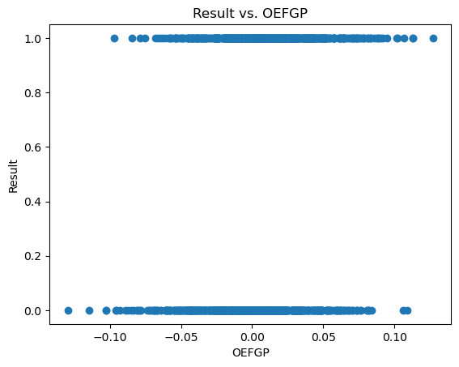

```python
scatter('OEFGP')
```

Seems like having a better effective field goal percentage on offense is strongly correlated with winning the matchup. This makes sense; the more frequently you make your field goals, the more likely you are to win.

### Defensive Effective Field Goal Percentage

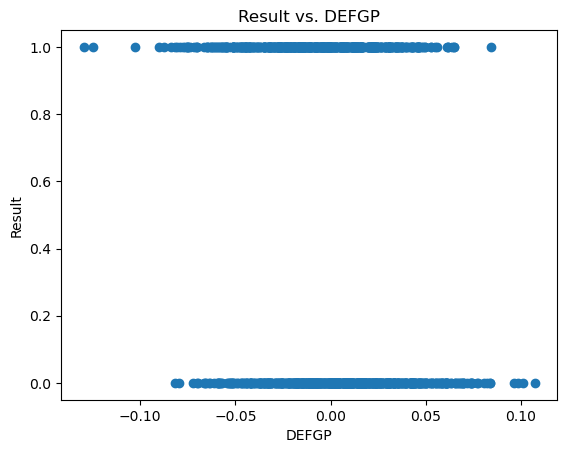

```python
scatter('DEFGP')
```

Similarly, having a better effective field goal percentage on defense is strongly correlated with winning the matchup. This may be underratedly important, but often times limiting the effective field goal percentage of the opponent is a result of having a stingy defense that prevents openings to shoot.

### Offensive Turnover Percentage

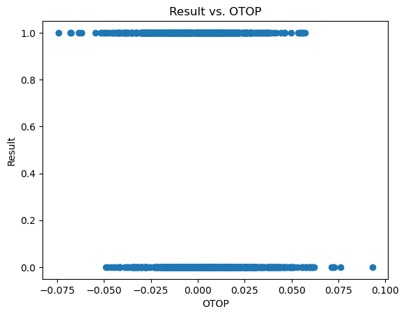

```python
scatter('OTOP')
```

Limiting the turnover percentage on offensive is strongly correlated with winning. This should be fairly obvious; it's hard to win when your team is constantly turning the ball over.

### Defensive Turnover Percentage

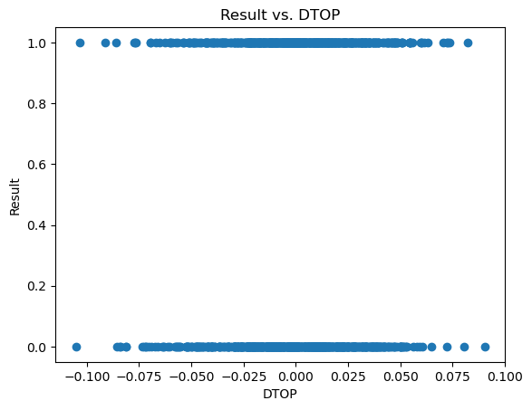

```python
scatter('DTOP')
```

This time, the correlation between turnover percentage on defense and winning is much weaker. This suggests that perhaps turnovers reflect more poorly on poor ball handling skills by the team that committed the turnover than well on the team that benefited from the turnover.

### Offensive Rebound Percentage

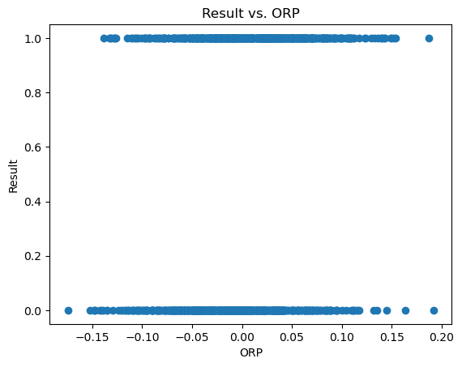

```python
scatter('ORP')
```

There seems to be a strong correlation between offensive rebounding percentage and winning. Commonly known for creating second chance points, this would make sense as by giving yourself more chances to score, the more likely you are to score.

### Defensive Rebound Percentage

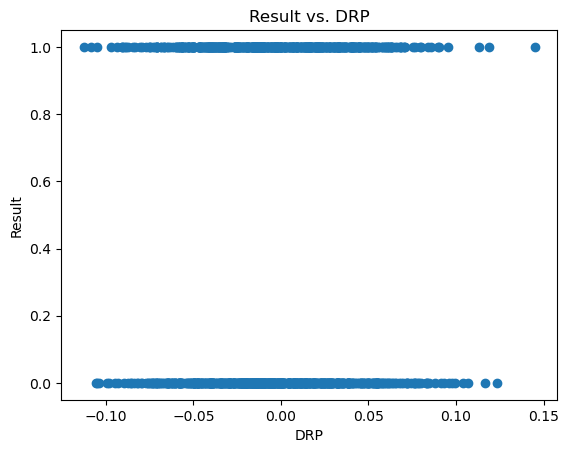

```python
scatter('DRP')
```

The correlation between defensive rebounding percentage and winning seems to be weak, but still existant. This could because in general, defensive rebounds are the expected rebounds. Offensive rebounds are just something extra, and reflects an extraordinary skill.

### Offensive Free Throw Factor

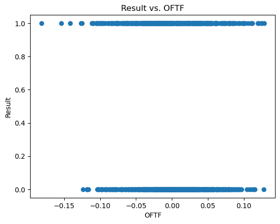

```python
scatter('OFTF')
```

The correlation seems to be a little weak with the offensive free throw factor and winning. Perhaps the free throw factor is more a sign of negligence by the other team.

### Defensive Free Throw Factor

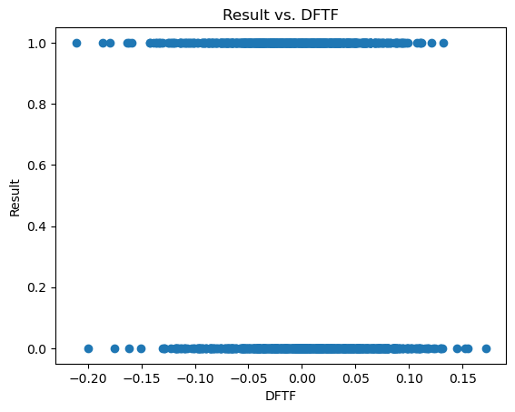

```python
scatter('DFTF')
```

The correlation between the defensive free throw factor and winning seems stronger here. This supports our observation from looking at the offensive free throw factor: more a sign of negligence to allow free throws than skill to get the free throws.

### Observations

In all the scatter plots, there is a relationship (the strength of the relationships varying significantly in strength) between the difference in the differential stat and the result of the matchup. For example, difference in point differentials seems to have a positive correlation with the result of the matchup (so a positive difference correlates to winning), while a difference in turnover differentials seems to have a negative correlation with the result of the matchup (negative difference correlates to winning).

## Feature Selection

Before we can build our regression model, we need to decide which features (team stats) we want to include in our model. While it may turn out that we use all eight factors, it is always best practice when developing a machine learning model that we at least employ **feature selection** methods to determine which input variables that will be relevant to building the model. What is so bad about having too many input variables? By increasing the complexity of the model, it may lead to overfitting as the model may consider features that are not relevant to the target variable.

Based on the scatter plots, the regression that would best suit this problem would be to showcase a [logistic regression](https://www.upgrad.com/blog/types-of-regression-models-in-machine-learning/) problem. The feature variables are numerical, numerical differences in team stats. The target variable is a *discrete* variable because it can only take two values for the result: 0 (loss) or 1 (win). But it is still a regression model because the ultimate goal is to predict a numeric probability of a win.

We will be using **Spearman's rank coefficient** as our feature selection method. I added a chart below, but remember that we are working with a regression predictive modeling problem: the probability that the team with the lower ID in the matchup wins. Hence our output is a numeric probability. Our input variables are numeric (we are dealing with basketball stats). Since logistic regression is a nonlinear correlation, we end up using Spearman's. Specifically, we will be calculating Spearman's coefficients for each of the features (basketball team stats) against the target variable, the result. For more information on selecting the feature selection method, look [here](https://machinelearningmastery.com/feature-selection-with-real-and-categorical-data/).

[figure not shown]

### Spearman's Rank Correlation

We have to ask ourselves the question: how will we use the Spearman coefficients for feature selection? We aren't exactly interested in the coefficient values (ranging from -1 to +1 to indicate strength of relationship), but rather the *significance* of those values. We need the **p-values** of these correlation values -- the probability of observing values as extreme or more given that the **null hypothesis** (no relationship between the difference in differential stat and the result) is true. And to do that, we need to use the `spearmanr` function from `scipy` to get not only the coefficient, but the p-value associated with it as well. The `scipy` library is important for conducting various mathematical and statistical analyses, such as conducting a statistical test as we are doing here. Here is the [scipy documentation](https://docs.scipy.org/doc/scipy/index.html) if you are interested.

Let's import `scipy` first.

```python
from scipy import stats
```

Let's create new DataFrame to showcase all the Spearman coefficients, as well as their p-values.

```python
# Store Spearman correlation between columns
corrs = []

# Store p-values for correlation values
p_vals = []
```

```python
# Iterate through every feature
for feature in features:

    # Find coorelation coefficient and associated p-value
    corr, p_val = stats.spearmanr(detailed_tourney_results[feature], detailed_tourney_results['Result'])

    # Append to lists storing entry values for DataFrame
    corrs.append(corr)
    p_vals.append(p_val)
```

```python
# Create the DataFrame for the correlation pairings
corr_mat = pd.DataFrame({
    'Feature'    : features,
    'Correlation': corrs,
    'p-value'    : p_vals
})

corr_mat
```

|  | Feature | Correlation | p-value |
| --- | --- | --- | --- |
| 0 | OEFGP | 0.178995 | 5.833228e-10 |
| 1 | DEFGP | -0.209521 | 3.500670e-13 |
| 2 | OTOP | -0.215311 | 7.468036e-14 |
| 3 | DTOP | 0.054432 | 6.148582e-02 |
| 4 | ORP | 0.213472 | 1.225739e-13 |
| 5 | DRP | 0.027340 | 3.478640e-01 |
| 6 | OFTF | -0.065634 | 2.409552e-02 |
| 7 | DFTF | -0.159175 | 3.809696e-08 |

It seems like at a significance level of 0.05, all the features except **DTOP** (which we said observationally seemed to have a weak correlation) and **DRP** (which we also said had a weak correlation) have a statistically significant correlation with the result. The one surprise is **OFTF**, but again of all features that having a statistically significant correlation, it is still by far the weakest one.

## Machine Learning

We will primarily be using the *scikit-learn* library for this part. This library is a common library used for machine learning, especially for basic regression and classification algorithms. Full documentation can be found [here](https://scikit-learn.org/stable/index.html).

```python
from sklearn.metrics import log_loss
from sklearn.model_selection import train_test_split
from sklearn.linear_model import LogisticRegression
```

### Feature Selection

Select all the features that are statistically significant at an alpha-level of 0.05. We need to update the `features` list.

```python
features = list(corr_mat[corr_mat['p-value'] <= 0.05]['Feature'].values)
features
```

```
['OEFGP', 'DEFGP', 'OTOP', 'ORP', 'OFTF', 'DFTF']
```

### Holdout Validation

We need to split the data set into training and testing data. When we actually submit our model to the Kaggle tournament, we will train on all the data available because the Kaggle submission will test on data that none of our datasets have access to. However, when we want to evaulate the effectiveness of our model, like right now, it is absolutely necessary to split the data. Otherwise, we would be evaluating the effectiveness of our model to predict data it has already been trained on, and we would have severe overfitting. For more information, check out [here](https://www.techtarget.com/searchenterpriseai/definition/data-splitting#:~:text=Data%20splitting%20separates%20data%20among,testing%20data.).

```python
# Define independent variables
X = detailed_tourney_results[features]
```

```python
# Use random state to replicate results
X_train, X_test, y_train, y_test = train_test_split(X, y, random_state=1)
```

### Training

We are finally at the fun part: training the model! We know what type of regression to use: **Logistic Regression**. So we can create the model, which is much simpler that it sounds (the few times this is true in life).

```python
model = LogisticRegression()
model.fit(X_train, y_train)
```

```
LogisticRegression()
```

That's it!

### Evaluation

Let's see how our model did. According to tournament rules, models are evaluated by minimizing log loss. Log loss is the prevailed metric for working with probabilities. To learn more about this metric, see [here](https://www.kaggle.com/code/dansbecker/what-is-log-loss/notebook).

We will need the `numpy` package to work with `numpy` arrays used in evaluation. The `numpy` library is useful for working with various features with n-dimensional arrays. Full documentation is [here](https://numpy.org/).

```python
import numpy as np
```

We need to use the `predict_proba` function because we are interested in probabilities of each target value, not in predicting the actual outcome.

```python
# predict_proba returns the probability for classes 0 and 1, respectively
# From there, we want the probability of class 1 (winning)
y_pred = [proba[1] for proba in model.predict_proba(X_test)]

# Convert to Pandas series so same data type as y_test (https://www.geeksforgeeks.org/convert-a-numpy-array-to-a-pandas-series/)
y_pred = pd.Series(np.array(y_pred))

# Get log loss
val_log_loss = log_loss(y_test, y_pred)
print(f'Validation Log Loss for Logarithmic Regression Model: {val_log_loss}')
```

```
Validation Log Loss for Logarithmic Regression Model: 0.6514411100488164
```

Let's see how this compares to our actual submission, when we train on the full data.

## Submission

It turns out that we do not have the DataFrame for submission completely ready yet. So we will need to recreate the data pipeline, but we can speed run it since many of the steps repeat themselves from earlier.

### Data Preprocessing

We create our DataFrame and define the columns for the 2022 tournament matchups. Notice that the columns are essentially the same as with the DataFrame for past tournament results, except we don't have a results column.

```python
# Store matchup IDs
ids = []

# Deconstruct the ID for data representation purposes

# Seasons
seasons = []

# Names of teams with smaller ID (XXXX)
teams1 = []

# Names of teams with larger ID (YYYY)
teams2 = []
```

```python
# Difference in team stats for each matchup in the 2022 tournament

# Offensive Effective Field Goal Percentage
oefgp = []

# Defensive Effective Field Goal Percentage
defgp = []

# Offensive Turnover Percentage
otop = []

# Defensive Turnover Percentage
dtop = []

# Offesive Rebound Percentage
orp = []

# Defensive Rebound Percentage
drp = []

# Offensive Free Throw Factor
oftf = []

# Defensive Free Throw Factor
dftf = []
```

Let's also create a filtered DataFrame of the `detailed_seeds` to have available stats for only the 2022 tournament seeds.

```python
current_tourney_seeds = detailed_tourney_seeds[detailed_tourney_seeds['Season'] == 2022]
```

We also need the set of unique teams competing in the tournament. Let's get them in sorted order; that way it will be easier to iterate through all the pairs and add to the entries cleanly.

```python
unique_teams = list(current_tourney_seeds['TeamID'].unique())
unique_teams.sort()
```

Now we iterate through all the teams and build the DataFrame entries one-by-one.

```python
for i in range(len(unique_teams) - 1):
    for j in range(i + 1, len(unique_teams)):
        team1_id, team2_id = unique_teams[i], unique_teams[j]

        # Look at how easy it is to add features with the helper function
        add_features(2022, team1_id, team2_id)
```

```python
tourney_matchups = pd.DataFrame({
    'ID'    : ids,
    'Season': seasons,
    'Team1' : teams1,
    'Team2' : teams2,
    'OEFGP' : oefgp,
    'DEFGP' : defgp,
    'OTOP'  : otop,
    'DTOP'  : dtop,
    'ORP'   : orp,
    'DRP'   : drp,
    'OFTF'  : oftf,
    'DFTF'  : dftf,
})

tourney_matchups.head()
```

|  | ID | Season | Team1 | Team2 | OEFGP | DEFGP | OTOP | DTOP | ORP | DRP | OFTF | DFTF |
| --- | --- | --- | --- | --- | --- | --- | --- | --- | --- | --- | --- | --- |
| 0 | 2022_1103_1104 | 2022 | Akron | Alabama | 0.013242 | -0.000943 | -0.013080 | -0.001942 | -0.062476 | 0.053504 | 0.032447 | -0.066027 |
| 1 | 2022_1103_1112 | 2022 | Akron | Arizona | -0.031243 | 0.049416 | -0.003823 | 0.002342 | -0.063034 | 0.017015 | 0.018244 | 0.031530 |
| 2 | 2022_1103_1116 | 2022 | Akron | Arkansas | 0.035933 | 0.018402 | 0.003945 | -0.032594 | -0.014675 | -0.011022 | -0.008033 | -0.052271 |
| 3 | 2022_1103_1120 | 2022 | Akron | Auburn | 0.024491 | 0.052024 | 0.011923 | -0.024254 | -0.035130 | 0.020345 | 0.045904 | -0.069482 |
| 4 | 2022_1103_1124 | 2022 | Akron | Baylor | -0.000814 | 0.014885 | 0.001558 | -0.046492 | -0.069087 | 0.028200 | 0.078289 | -0.004188 |

### Machine Learning

For the submission, we no longer need to conduct holdout validation. We can fit on the full data instead.

```python
# Fit lineaer regression model on full data this time
model = LogisticRegression()
model.fit(X, y)
```

```
LogisticRegression()
```

### Model Predictions

We need to extract the features to predict from the current tournament seeds for 2022.

```python
X = tourney_matchups[features]
X.head()
```

|  | OEFGP | DEFGP | OTOP | ORP | OFTF | DFTF |
| --- | --- | --- | --- | --- | --- | --- |
| 0 | 0.013242 | -0.000943 | -0.013080 | -0.062476 | 0.032447 | -0.066027 |
| 1 | -0.031243 | 0.049416 | -0.003823 | -0.063034 | 0.018244 | 0.031530 |
| 2 | 0.035933 | 0.018402 | 0.003945 | -0.014675 | -0.008033 | -0.052271 |
| 3 | 0.024491 | 0.052024 | 0.011923 | -0.035130 | 0.045904 | -0.069482 |
| 4 | -0.000814 | 0.014885 | 0.001558 | -0.069087 | 0.078289 | -0.004188 |

```python
# Make predictions to submit (again using predict_proba)
pred = [proba[1] for proba in model.predict_proba(X)]
```

And now we create the output DataFrame that will be converted into a csv file of our predictions of every possible matchup.

```python
output = pd.DataFrame({
    'ID'  : tourney_matchups.ID,
    'Pred': pred
})

output.head()
```

|  | ID | Pred |
| --- | --- | --- |
| 0 | 2022_1103_1104 | 0.472718 |
| 1 | 2022_1103_1112 | 0.348660 |
| 2 | 2022_1103_1116 | 0.510354 |
| 3 | 2022_1103_1120 | 0.451987 |
| 4 | 2022_1103_1124 | 0.390307 |

```python
# Create CSV submission file
output.to_csv('submission.csv', index=False)
```

## Conclusion

When I submitted `submission.csv` to the [Kaggle tournament](https://www.kaggle.com/competitions/mens-march-mania-2022/submissions#), I got a log loss of **0.66941**. If we were to look at the [leaderboard](https://www.kaggle.com/competitions/mens-march-mania-2022/leaderboard#), it would turn out that I would rank **553rd** out of **930** teams. This is nothing too great, as it is below average in the tournament. However, the purpose of this project was not to create the best model of all time, but rather to demonstrate the data pipeline: the preprocessing and exploratory analysis we need to take to develop a working model.

There are several flaws with my approach. I may have implied this in the beginning, but we don't directly account for strength of opponent when we look at the four factors. How would we go about doing this next time? Perhaps, for example, when we are calculating offensive field goal percentage for a team in a given game, we need to compare that percentage with the offensive field goal percentage that the opponent gives up on average. That way, we get a fixed benchmark to evaluate the team against other teams that have played the opponent, and hence a better basis for calculating relative strength of the team in one or more stats.

Another flaw that I made was that I assumed that each factor was independent of each other when building my machine learning model. It is important that the features used in training a model are independent of each other, and this is a feature called [multicollinearity](https://towardsdatascience.com/assumptions-in-linear-regression-528bb7b0495d). In reality, however, the features do interact with each other to a small extent. For example, offensive rebounds may lead to a better offensive effective field goal percentage. The factors are calculated in a manner that the factors interact with each other as little as possible, but there is always some correlation.

Nevertheless, this is the whole data pipeline for building a machine learning model. First we conduct data preprocessing with the datasets to get a data table in the format of data we need to make predictions. Next we do some exploratory analysis to look at which features correlate with the target variable and select our features from there. Then we would try different machine learning algorithms that could potentially best capture the relationship between the features and the target variable, making sure to split the data into training and testing sets beforehand. I only did logistic regression for this tutorial since I felt this regression technique modeled the relationship to a T. Last we evaluate each algorithm, see which one yields the most accurate results, and build a final machine learning model that trains on all the data, because from now we will be testing on data the machine learning model has never seen.

Again, here is the [Kaggle challenge](https://www.kaggle.com/competitions/mens-march-mania-2022/overview) if you are interested in trying this experiment for yourself. I found [this tutorial from Kaggle](https://www.kaggle.com/learn/intro-to-machine-learning) especially useful in getting yourself acquainted with the pipeline for building machine learning models, and should give you a foothold into building many simple machine learning models. Happy training!

Before I sign off, here is what my predicted bracket for the 2022 tournament would look like if everything played out in a (predicted) probablistic world, created thanks to [this fan-built webpage](https://wncviz.com/demos/NCAA_Brackets/kaggle_brackets.html). Just submit your submission CSV and it will create the bracket for you! A few notes about this to avoid confusion.

- The **Average Log Loss** is the average loss loss of each prediction to the result *if* this were the actual bracket.
- The numbers next to each game are not the predicted scores, but the probability of the given team winning the game.

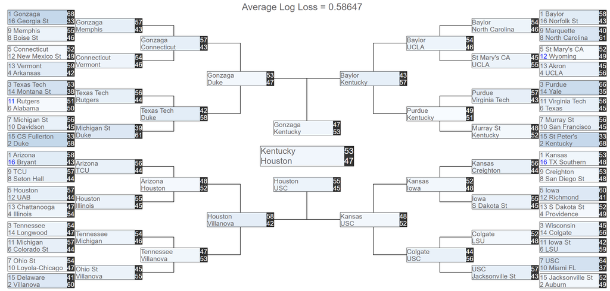